# Biostat 203B Homework 2

Due Feb 8 Feb 11, 2026 @ 11:59PM

Author

Rebekah Patel and 605566820

Load necessary libraries (you can add more as needed).

```r
library(arrow)
library(data.table)
library(duckdb)
library(memuse)
library(pryr)
library(R.utils)
library(tidyverse)
```

Display memory information of your computer

```r
memuse::Sys.meminfo()
```

```
Totalram:    8.000 GiB
Freeram:   211.875 MiB
```

In this exercise, we explore various tools for ingesting the [MIMIC-IV](https://physionet.org/content/mimiciv/3.1/) data introduced in [homework 1](https://ucla-biostat-203b.github.io/2026winter/hw/hw1/hw1.html).

Display the contents of MIMIC `hosp` and `icu` data folders:

```bash
ls -l ~/mimic/hosp/
```

```
total 12306256
-rwx------@ 1 rebekahpatel  staff    19928140 Jun 24  2024 admissions.csv.gz
-rwx------@ 1 rebekahpatel  staff      427554 Apr 12  2024 d_hcpcs.csv.gz
-rwx------@ 1 rebekahpatel  staff      876360 Apr 12  2024 d_icd_diagnoses.csv.gz
-rwx------@ 1 rebekahpatel  staff      589186 Apr 12  2024 d_icd_procedures.csv.gz
-rwx------@ 1 rebekahpatel  staff       13169 Oct  3  2024 d_labitems.csv.gz
-rwx------@ 1 rebekahpatel  staff    33564802 Oct  3  2024 diagnoses_icd.csv.gz
-rwx------@ 1 rebekahpatel  staff     9743908 Oct  3  2024 drgcodes.csv.gz
-rwx------@ 1 rebekahpatel  staff   811305629 Apr 12  2024 emar.csv.gz
-rwx------@ 1 rebekahpatel  staff   748158322 Apr 12  2024 emar_detail.csv.gz
-rwx------@ 1 rebekahpatel  staff     2162335 Apr 12  2024 hcpcsevents.csv.gz
-rwx------@ 1 rebekahpatel  staff        2907 Dec 28  2024 index.html
-rwx------@ 1 rebekahpatel  staff  2592909134 Jan 19 13:02 labevents.csv.gz
-rwx------@ 1 rebekahpatel  staff   117644075 Oct  3  2024 microbiologyevents.csv.gz
-rwx------@ 1 rebekahpatel  staff    44069351 Oct  3  2024 omr.csv.gz
-rwx------@ 1 rebekahpatel  staff     2835586 Apr 12  2024 patients.csv.gz
-rwx------@ 1 rebekahpatel  staff   525708076 Apr 12  2024 pharmacy.csv.gz
-rwx------@ 1 rebekahpatel  staff   666594177 Apr 12  2024 poe.csv.gz
-rwx------@ 1 rebekahpatel  staff    55267894 Apr 12  2024 poe_detail.csv.gz
-rwx------@ 1 rebekahpatel  staff   606298611 Apr 12  2024 prescriptions.csv.gz
-rwx------@ 1 rebekahpatel  staff     7777324 Apr 12  2024 procedures_icd.csv.gz
-rwx------@ 1 rebekahpatel  staff      127330 Apr 12  2024 provider.csv.gz
-rwx------@ 1 rebekahpatel  staff     8569241 Apr 12  2024 services.csv.gz
-rwx------@ 1 rebekahpatel  staff    46185771 Oct  3  2024 transfers.csv.gz
```

```bash
ls -l ~/mimic/icu/
```

```
total 8535480
-rwx------@ 1 rebekahpatel  staff       41566 Apr 12  2024 caregiver.csv.gz
-rwx------@ 1 rebekahpatel  staff  3502392765 Apr 12  2024 chartevents.csv.gz
-rwx------@ 1 rebekahpatel  staff       58741 Apr 12  2024 d_items.csv.gz
-rwx------@ 1 rebekahpatel  staff    63481196 Apr 12  2024 datetimeevents.csv.gz
-rwx------@ 1 rebekahpatel  staff    14686092 Feb 22  2025 icustays.csv
-rwx------@ 1 rebekahpatel  staff     3342355 Oct  3  2024 icustays.csv.gz
-rwx------@ 1 rebekahpatel  staff        1336 Dec 28  2024 index.html
-rwx------@ 1 rebekahpatel  staff   311642048 Apr 12  2024 ingredientevents.csv.gz
-rwx------@ 1 rebekahpatel  staff   401088206 Apr 12  2024 inputevents.csv.gz
-rwx------@ 1 rebekahpatel  staff    49307639 Apr 12  2024 outputevents.csv.gz
-rwx------@ 1 rebekahpatel  staff    24096834 Apr 12  2024 procedureevents.csv.gz
```

## Q1. `read.csv` (base R) vs `read_csv` (tidyverse) vs `fread` (data.table)

### Q1.1 Speed, memory, and data types

There are quite a few utilities in R for reading plain text data files. Let us test the speed of reading a moderate sized compressed csv file, `admissions.csv.gz`, by three functions: `read.csv` in base R, `read_csv` in tidyverse, and `fread` in the data.table package.

Which function is fastest? Is there difference in the (default) parsed data types? How much memory does each resultant dataframe or tibble use? (Hint: `system.time` measures run times; `pryr::object_size` measures memory usage; all these readers can take gz file as input without explicit decompression.)

```r
system.time(read.csv("~/mimic/hosp/admissions.csv.gz"))
```

```
   user  system elapsed
 10.374   0.272  10.705
```

```r
system.time(read_csv("~/mimic/hosp/admissions.csv.gz"))
```

```
   user  system elapsed
  4.035   0.540   1.814
```

```r
system.time(fread("~/mimic/hosp/admissions.csv.gz"))
```

```
   user  system elapsed
  0.988   0.161   1.167
```

**Solution:** The fastest function is `fread` from the data.table package. The default parsed data types are different among the three functions. `read.csv` reads character columns as factors by default, while `read_csv` and `fread` read character columns as characters.

```r
pryr::object_size(read.csv("~/mimic/hosp/admissions.csv.gz"))
```

```
200.10 MB
```

```r
pryr::object_size(read_csv("~/mimic/hosp/admissions.csv.gz"))
```

```
70.02 MB
```

```r
pryr::object_size(fread("~/mimic/hosp/admissions.csv.gz"))
```

```
63.47 MB
```

**Solution:** The memory usage of the resultant dataframe or tibble is different among the three functions. `fread` generally uses less memory compared to `read.csv` and `read_csv`. However, `fread` and `read_csv` produce similar memory usage, which is substantially less than that of `read.csv`.

### Q1.2 User-supplied data types

Re-ingest `admissions.csv.gz` by indicating appropriate column data types in `read_csv`. Does the run time change? How much memory does the result tibble use? (Hint: `col_types` argument in `read_csv`; result tibble should be less than 50MB.)

```r
system.time(read_csv("~/mimic/hosp/admissions.csv.gz",
              col_types = list(
                subject_id = col_integer(),
                hadm_id = col_integer(),
                admittime = col_datetime(format = ""),
                dischtime = col_datetime(format = ""),
                deathtime = col_datetime(format = ""),
                admission_type = col_factor(NULL),
                admit_provider_id = col_character(),
                admission_location = col_factor(NULL),
                discharge_location = col_factor(NULL),
                insurance = col_factor(NULL),
                language = col_factor(NULL),
                marital_status = col_factor(NULL),
                race = col_factor(NULL),
                edregtime = col_datetime(format = ""),
                edouttime = col_datetime(format = ""),
                hospital_expire_flag = col_integer())))
```

```
   user  system elapsed
  3.496   0.473   1.365
```

```r
pryr::object_size(read_csv("~/mimic/hosp/admissions.csv.gz",
              col_types = list(
                subject_id = col_integer(),
                hadm_id = col_integer(),
                admittime = col_datetime(format = ""),
                dischtime = col_datetime(format = ""),
                deathtime = col_datetime(format = ""),
                admission_type = col_factor(NULL),
                admit_provider_id = col_character(),
                admission_location = col_factor(NULL),
                discharge_location = col_factor(NULL),
                insurance = col_factor(NULL),
                language = col_factor(NULL),
                marital_status = col_factor(NULL),
                race = col_factor(NULL),
                edregtime = col_datetime(format = ""),
                edouttime = col_datetime(format = ""),
                hospital_expire_flag = col_integer())))
```

```
48.19 MB
```

## Q2. Ingest big data files

[figure not shown]

Let us focus on a bigger file, `labevents.csv.gz`, which is about 130x bigger than `admissions.csv.gz`.

```bash
ls -l ~/mimic/hosp/labevents.csv.gz
```

```
-rwx------@ 1 rebekahpatel  staff  2592909134 Jan 19 13:02 /Users/rebekahpatel/mimic/hosp/labevents.csv.gz
```

Display the first 10 lines of this file.

```bash
zcat < ~/mimic/hosp/labevents.csv.gz | head -10
```

```
labevent_id,subject_id,hadm_id,specimen_id,itemid,order_provider_id,charttime,storetime,value,valuenum,valueuom,ref_range_lower,ref_range_upper,flag,priority,comments
1,10000032,,2704548,50931,P69FQC,2180-03-23 11:51:00,2180-03-23 15:56:00,___,95,mg/dL,70,100,,ROUTINE,"IF FASTING, 70-100 NORMAL, >125 PROVISIONAL DIABETES."
2,10000032,,36092842,51071,P69FQC,2180-03-23 11:51:00,2180-03-23 16:00:00,NEG,,,,,,ROUTINE,
3,10000032,,36092842,51074,P69FQC,2180-03-23 11:51:00,2180-03-23 16:00:00,NEG,,,,,,ROUTINE,
4,10000032,,36092842,51075,P69FQC,2180-03-23 11:51:00,2180-03-23 16:00:00,NEG,,,,,,ROUTINE,"BENZODIAZEPINE IMMUNOASSAY SCREEN DOES NOT DETECT SOME DRUGS,;INCLUDING LORAZEPAM, CLONAZEPAM, AND FLUNITRAZEPAM."
5,10000032,,36092842,51079,P69FQC,2180-03-23 11:51:00,2180-03-23 16:00:00,NEG,,,,,,ROUTINE,
6,10000032,,36092842,51087,P69FQC,2180-03-23 11:51:00,,,,,,,,ROUTINE,RANDOM.
7,10000032,,36092842,51089,P69FQC,2180-03-23 11:51:00,2180-03-23 16:15:00,,,,,,,ROUTINE,PRESUMPTIVELY POSITIVE.
8,10000032,,36092842,51090,P69FQC,2180-03-23 11:51:00,2180-03-23 16:00:00,NEG,,,,,,ROUTINE,METHADONE ASSAY DETECTS ONLY METHADONE (NOT OTHER OPIATES/OPIOIDS).
9,10000032,,36092842,51092,P69FQC,2180-03-23 11:51:00,2180-03-23 16:00:00,NEG,,,,,,ROUTINE,"OPIATE IMMUNOASSAY SCREEN DOES NOT DETECT SYNTHETIC OPIOIDS;SUCH AS METHADONE, OXYCODONE, FENTANYL, BUPRENORPHINE, TRAMADOL,;NALOXONE, MEPERIDINE.  SEE ONLINE LAB MANUAL FOR DETAILS."
```

### Q2.1 Ingest `labevents.csv.gz` by `read_csv`

[figure not shown]

Try to ingest `labevents.csv.gz` using `read_csv`. What happens? If it takes more than 3 minutes on your computer, then abort the program and report your findings.

```r
read_csv("~/mimic/hosp/labevents.csv.gz")
```

### Q2.2 Ingest selected columns of `labevents.csv.gz` by `read_csv`

Try to ingest only columns `subject_id`, `itemid`, `charttime`, and `valuenum` in `labevents.csv.gz` using `read_csv`. Does this solve the ingestion issue? (Hint: `col_select` argument in `read_csv`.)

```r
system.time(read_csv("~/mimic/hosp/labevents.csv.gz",
          col_select = c("subject_id", "itemid", "charttime", "valuenum")))
```

**Solution:** After 15 minutes, the `read_csv` function is still running and has not completed the ingestion of the selected columns from `labevents.csv.gz`, so I terminated the command. This suggests that simply selecting specific columns does not solve the ingestion issue, likely due to the sheer size of the file and the inefficiency of `read_csv` for handling such large datasets. Even though we are only selecting a subset of columns, `read_csv` may still be trying to read the entire file into memory before filtering out the unwanted columns, which can lead to performance issues and potential memory exhaustion. Therefore, alternative strategies may be needed to efficiently handle and process such large datasets.

### Q2.3 Ingest a subset of `labevents.csv.gz`

[figure not shown]

Our first strategy to handle this big data file is to make a subset of the `labevents` data. Read the [MIMIC documentation](https://mimic.mit.edu/docs/iv/modules/hosp/labevents/) for the content in data file `labevents.csv`.

In later exercises, we will only be interested in the following lab items: albumin (50862), creatinine (50912), potassium (50971), sodium (50983), chloride (50902), bicarbonate (50882), hematocrit (51221), white blood cell count (51301), and glucose (50931) and the following columns: `subject_id`, `itemid`, `charttime`, `valuenum`. Write a Bash command to extract these columns and rows from `labevents.csv.gz` and save the result to a new file `labevents_filtered.csv.gz` in the current working directory. (Hint: Use `zcat <` to pipe the output of `labevents.csv.gz` to `awk` and then to `gzip` to compress the output. Do **not** put `labevents_filtered.csv.gz` in Git! To save render time, you can put `#| eval: false` at the beginning of this code chunk. TA will change it to `#| eval: true` before rendering your qmd file.)

Display the first 10 lines of the new file `labevents_filtered.csv.gz`. How many lines are in this new file, excluding the header? How long does it take `read_csv` to ingest `labevents_filtered.csv.gz`?

```bash
gzcat < ~/mimic/hosp/labevents.csv.gz | \
  awk -F, 'NR==1 {print $2, $5, $7, $10; next}
  $5==50862 || $5==50912 || $5==50971 || $5==50983 ||
  $5==50902 || $5==50882 || $5==51221 || $5==51301 ||
  $5==50931 {print $2, $5, $7 ,$10}' | \
  gzip > ~/BIOSTAT203B/203b-hw/hw2/labevents_filtered.csv.gz
```

```bash
gzcat < labevents_filtered.csv.gz | head -10
```

```
subject_id itemid charttime valuenum
10000032 50931 2180-03-23 11:51:00 95
10000032 50862 2180-03-23 11:51:00 3.3
10000032 50882 2180-03-23 11:51:00 27
10000032 50902 2180-03-23 11:51:00 101
10000032 50912 2180-03-23 11:51:00 0.4
10000032 50971 2180-03-23 11:51:00 3.7
10000032 50983 2180-03-23 11:51:00 136
10000032 51221 2180-03-23 11:51:00 45.4
10000032 51301 2180-03-23 11:51:00 3
```

```bash
gzcat < labevents_filtered.csv.gz | wc -l
```

```
 33712353
```

```r
system.time(read_csv("labevents_filtered.csv.gz"))
```

[output not shown]

**Solution:** There are 33,712,352 lines, excluding the header. The time taken by `read_csv` to read labevents_filtered.csv.gz is user 162.173 seconds and elapsed time is 425.971 seconds. It took around 30 minutes to filter labevents and create the zipped file labevents_filtered.csv.gz.

### Q2.4 Ingest `labevents.csv` by Apache Arrow

[figure not shown]

Our second strategy is to use [Apache Arrow](https://arrow.apache.org/) for larger-than-memory data analytics. Unfortunately Arrow does not work with gz files directly. First decompress `labevents.csv.gz` to `labevents.csv` and put it in the current working directory (do not add it in Git!). To save render time, put `#| eval: false` at the beginning of this code chunk. TA will change it to `#| eval: true` when rendering your qmd file.

Then use [`arrow::open_dataset`](https://arrow.apache.org/docs/r/reference/open_dataset.html) to ingest `labevents.csv`, select columns, and filter `itemid` as in Q2.3. How long does the ingest+select+filter process take? Display the number of rows and the first 10 rows of the result tibble, and make sure they match those in Q2.3. (Hint: use `dplyr` verbs for selecting columns and filtering rows.)

Write a few sentences to explain what Apache Arrow is. Imagine you want to explain it to a layman in an elevator.

```bash
gzip -dk < ~/mimic/hosp/labevents.csv.gz > labevents.csv
```

```r
system.time(labevents_csv <- open_dataset("labevents.csv", format = "csv") |>
  select(subject_id, itemid, charttime, valuenum) |>
  filter(itemid %in% c(50862, 50912, 50971, 50983, 50902, 50882, 51221, 51301, 50931)) |>
  arrange(subject_id, charttime, itemid) |>
  collect())
```

```
   user  system elapsed
 84.778  12.653  81.625
```

```r
nrow(labevents_csv)
```

```
[1] 33712352
```

```r
head(labevents_csv, 10)
```

```
# A tibble: 10 × 4
   subject_id itemid charttime           valuenum
        <int>  <int> <dttm>                 <dbl>
 1   10000032  50862 2180-03-23 04:51:00      3.3
 2   10000032  50882 2180-03-23 04:51:00     27
 3   10000032  50902 2180-03-23 04:51:00    101
 4   10000032  50912 2180-03-23 04:51:00      0.4
 5   10000032  50931 2180-03-23 04:51:00     95
 6   10000032  50971 2180-03-23 04:51:00      3.7
 7   10000032  50983 2180-03-23 04:51:00    136
 8   10000032  51221 2180-03-23 04:51:00     45.4
 9   10000032  51301 2180-03-23 04:51:00      3
10   10000032  50862 2180-05-06 15:25:00      3.3
```

### Q2.5 Compress `labevents.csv` to Parquet format and ingest/select/filter

[figure not shown]

Re-write the csv file `labevents.csv` in the binary Parquet format (Hint: [`arrow::write_dataset`](https://arrow.apache.org/docs/r/reference/write_dataset.html).) How large is the Parquet file(s)? How long does the ingest+select+filter process of the Parquet file(s) take? Display the number of rows and the first 10 rows of the result tibble and make sure they match those in Q2.3. (Hint: use `dplyr` verbs for selecting columns and filtering rows.)

Write a few sentences to explain what the Parquet format is. Imagine you want to explain it to a layman in an elevator.

```r
pq_dir <- "pq_files"
system.time(
  write_dataset(
    dataset = open_dataset("labevents.csv", format = "csv"),
    path = pq_dir,
    format = "parquet"
  )
)
```

```
   user  system elapsed
301.122  56.260 247.521
```

```r
file_info <- tibble(
  files = list.files(pq_dir, recursive = TRUE),
  size_MB = file.size(file.path(pq_dir, files)) / 1024^2
)
print(file_info)
```

```
# A tibble: 1 × 2
  files          size_MB
  <chr>            <dbl>
1 part-0.parquet   2618.
```

```r
system.time(
  labevents_pq <- open_dataset(pq_dir, format = "parquet") |>
    select(subject_id, itemid, charttime, valuenum) |>
    filter(itemid %in% c(50862, 50912, 50971, 50983, 50902,
                         50882, 51221, 51301, 50931)) |>
    arrange(subject_id, charttime, itemid) |>
    collect()
)
```

```
   user  system elapsed
 47.148  14.305  17.695
```

```r
nrow(labevents_pq)
```

```
[1] 33712352
```

```r
head(labevents_pq, 10)
```

```
# A tibble: 10 × 4
   subject_id itemid charttime           valuenum
        <int>  <int> <dttm>                 <dbl>
 1   10000032  50862 2180-03-23 04:51:00      3.3
 2   10000032  50882 2180-03-23 04:51:00     27
 3   10000032  50902 2180-03-23 04:51:00    101
 4   10000032  50912 2180-03-23 04:51:00      0.4
 5   10000032  50931 2180-03-23 04:51:00     95
 6   10000032  50971 2180-03-23 04:51:00      3.7
 7   10000032  50983 2180-03-23 04:51:00    136
 8   10000032  51221 2180-03-23 04:51:00     45.4
 9   10000032  51301 2180-03-23 04:51:00      3
10   10000032  50862 2180-05-06 15:25:00      3.3
```

```r
print(file_info)
```

```
# A tibble: 1 × 2
  files          size_MB
  <chr>            <dbl>
1 part-0.parquet   2618.
```

### Q2.6 DuckDB

[figure not shown]

Ingest the Parquet file, convert it to a DuckDB table by [`arrow::to_duckdb`](https://arrow.apache.org/docs/r/reference/to_duckdb.html), select columns, and filter rows as in Q2.5. How long does the ingest+convert+select+filter process take? Display the number of rows and the first 10 rows of the result tibble and make sure they match those in Q2.3. (Hint: use `dplyr` verbs for selecting columns and filtering rows.)

Write a few sentences to explain what DuckDB is. Imagine you want to explain it to a layman in an elevator.

```r
system.time(
  labevents_duckdb <- open_dataset(pq_dir) |>
    to_duckdb() |>
    select(subject_id, itemid, charttime, valuenum) |>
    filter(itemid %in% c(50862, 50912, 50971, 50983, 50902,
                         50882, 51221, 51301, 50931)) |>
    arrange(subject_id, charttime, itemid) |>
    collect()
)
```

```
   user  system elapsed
106.230  40.442  34.362
```

```r
nrow(labevents_duckdb)
```

```
[1] 33712352
```

```r
head(labevents_duckdb, 10)
```

```
# A tibble: 10 × 4
   subject_id itemid charttime           valuenum
        <dbl>  <dbl> <dttm>                 <dbl>
 1   10000032  50862 2180-03-23 11:51:00      3.3
 2   10000032  50882 2180-03-23 11:51:00     27
 3   10000032  50902 2180-03-23 11:51:00    101
 4   10000032  50912 2180-03-23 11:51:00      0.4
 5   10000032  50931 2180-03-23 11:51:00     95
 6   10000032  50971 2180-03-23 11:51:00      3.7
 7   10000032  50983 2180-03-23 11:51:00    136
 8   10000032  51221 2180-03-23 11:51:00     45.4
 9   10000032  51301 2180-03-23 11:51:00      3
10   10000032  50862 2180-05-06 22:25:00      3.3
```

## Q3. Ingest and filter `chartevents.csv.gz`

[`chartevents.csv.gz`](https://mimic.mit.edu/docs/iv/modules/icu/chartevents/) contains all the charted data available for a patient. During their ICU stay, the primary repository of a patient’s information is their electronic chart. The `itemid` variable indicates a single measurement type in the database. The `value` variable is the value measured for `itemid`. The first 10 lines of `chartevents.csv.gz` are

```bash
zcat < ~/mimic/icu/chartevents.csv.gz | head -10
```

```
subject_id,hadm_id,stay_id,caregiver_id,charttime,storetime,itemid,value,valuenum,valueuom,warning
10000032,29079034,39553978,18704,2180-07-23 12:36:00,2180-07-23 14:45:00,226512,39.4,39.4,kg,0
10000032,29079034,39553978,18704,2180-07-23 12:36:00,2180-07-23 14:45:00,226707,60,60,Inch,0
10000032,29079034,39553978,18704,2180-07-23 12:36:00,2180-07-23 14:45:00,226730,152,152,cm,0
10000032,29079034,39553978,18704,2180-07-23 14:00:00,2180-07-23 14:18:00,220048,SR (Sinus Rhythm),,,0
10000032,29079034,39553978,18704,2180-07-23 14:00:00,2180-07-23 14:18:00,224642,Oral,,,0
10000032,29079034,39553978,18704,2180-07-23 14:00:00,2180-07-23 14:18:00,224650,None,,,0
10000032,29079034,39553978,18704,2180-07-23 14:00:00,2180-07-23 14:20:00,223761,98.7,98.7,°F,0
10000032,29079034,39553978,18704,2180-07-23 14:11:00,2180-07-23 14:17:00,220179,84,84,mmHg,0
10000032,29079034,39553978,18704,2180-07-23 14:11:00,2180-07-23 14:17:00,220180,48,48,mmHg,0
```

How many rows? 433 millions.

```bash
zcat < ~/mimic/icu/chartevents.csv.gz | tail -n +2 | wc -l
```

**Solution:** After 10 minutes, the command is still running and has not completed counting the number of rows in `chartevents.csv.gz`, so I terminated the command.

[`d_items.csv.gz`](https://mimic.mit.edu/docs/iv/modules/icu/d_items/) is the dictionary for the `itemid` in `chartevents.csv.gz`.

```bash
zcat < ~/mimic/icu/d_items.csv.gz | head -10
```

```
itemid,label,abbreviation,linksto,category,unitname,param_type,lownormalvalue,highnormalvalue
220001,Problem List,Problem List,chartevents,General,,Text,,
220003,ICU Admission date,ICU Admission date,datetimeevents,ADT,,Date and time,,
220045,Heart Rate,HR,chartevents,Routine Vital Signs,bpm,Numeric,,
220046,Heart rate Alarm - High,HR Alarm - High,chartevents,Alarms,bpm,Numeric,,
220047,Heart Rate Alarm - Low,HR Alarm - Low,chartevents,Alarms,bpm,Numeric,,
220048,Heart Rhythm,Heart Rhythm,chartevents,Routine Vital Signs,,Text,,
220050,Arterial Blood Pressure systolic,ABPs,chartevents,Routine Vital Signs,mmHg,Numeric,90,140
220051,Arterial Blood Pressure diastolic,ABPd,chartevents,Routine Vital Signs,mmHg,Numeric,60,90
220052,Arterial Blood Pressure mean,ABPm,chartevents,Routine Vital Signs,mmHg,Numeric,,
```

In later exercises, we are interested in the vitals for ICU patients: heart rate (220045), mean non-invasive blood pressure (220181), systolic non-invasive blood pressure (220179), body temperature in Fahrenheit (223761), and respiratory rate (220210). Retrieve a subset of `chartevents.csv.gz` only containing these items, using the favorite method you learnt in Q2.

Document the steps and show code. Display the number of rows and the first 10 rows of the result tibble.

```r
pq_chart_dir <- "pq_chart"
pq_chart <- write_dataset(
  dataset = open_dataset("~/mimic/icu/chartevents.csv.gz", format = "csv"),
  path = pq_chart_dir,
  format = "parquet"
)

chartevents_subset <- open_dataset(pq_chart_dir, format = "parquet") |>
  to_duckdb() |>
  select(subject_id, itemid, charttime, valuenum) |>
  filter(itemid %in% c(220045, 220181, 220179, 223761, 220210)) |>
  arrange(subject_id, charttime, itemid) |>
  collect()
```

```r
nrow(chartevents_subset)
```

```
[1] 30195426
```

```r
head(chartevents_subset, 10)
```

```
# A tibble: 10 × 4
   subject_id itemid charttime           valuenum
        <dbl>  <dbl> <dttm>                 <dbl>
 1   10000032 223761 2180-07-23 14:00:00     98.7
 2   10000032 220179 2180-07-23 14:11:00     84
 3   10000032 220181 2180-07-23 14:11:00     56
 4   10000032 220045 2180-07-23 14:12:00     91
 5   10000032 220210 2180-07-23 14:12:00     24
 6   10000032 220045 2180-07-23 14:30:00     93
 7   10000032 220179 2180-07-23 14:30:00     95
 8   10000032 220181 2180-07-23 14:30:00     67
 9   10000032 220210 2180-07-23 14:30:00     21
10   10000032 220045 2180-07-23 15:00:00     94
```

**Solution:** I rewrote `chartevents.csv.gz` into Parquet files, creating a folder called pq_chart to hold the Parquet files. Then I ingested+selected+filtered the files with DuckDB utilizing Apache Arrow’s open_dataset(), to_duckdb(), and dplyr functions. I selected the four columns desired, subject_id, itemid, charttime, and valuenum, and filtered for the five itemids of interest. I then ordered the resulting tibble.

## Q4. AI assistant

Which AI assistants (e.g., GitHub Copilot) do you use when working on this assignment? Which AI model (e.g., GPT-5 mini, GPT-5, Claude Sonnet 4.5) does the AI assistant use? How do you use them? Do you think they help improve your productivity?

Give 5 instances where AI model gave incorrect or misleading answers. You can use screenshots or copy-paste the Q&A. **Solution:** I used GitHub Copilot to help generate code snippets and provide suggestions while working on the assignment. It has been helpful in improving my productivity by offering quick solutions and ideas for coding tasks. However, there were instances where the AI model gave incorrect or misleading answers, such as suggesting inefficient code, providing incorrect syntax, or misunderstanding the context of the problem. I have documented these instances with screenshots and copy-pasted Q&A for reference. I also used Claude, Sonnet 4.5 model, to help with debugging, storage issues, and questions on why my code took too long.

1. Copilot suggested incorrect Linux code to filtering labevents.csv.gz.

[figure not shown]

2. Copilot suggested selecting certain columns from a dataset when it was not asked in the question.

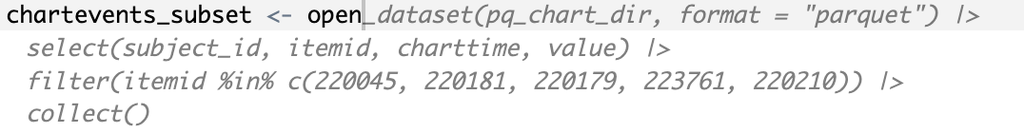

3. Copilot suggested the wrong runtimes to describe the previously run code.

[figure not shown]

4. Copilot suggested more incorrect runtimes to another command.

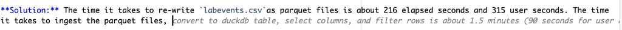

5. Copilot suggested incorrect file sizes in the commentary of file storage.

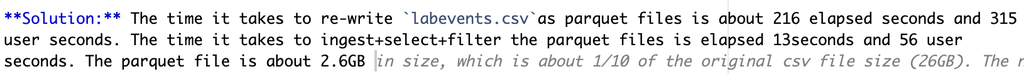